# Annotated Logistic Regression Report: U.S. Quality of Life (2024)

Samuel Gu

2025-05-29

## 1. Problem Statement

This report models whether a U.S. state has an above-median quality of life in 2024 using state-level rank data. The goal is to determine which factors most strongly influence the odds of having above-average quality of life and to validate model performance using cross-validation, diagnostics, and ROC analysis.

> **Commentary**:  
> This sets the stage for the analysis. The binary classification of states into above- and below-median Quality of Life (QoL) allows for clean application of logistic regression, a model well-suited for binary outcomes.

## 2. Data Overview

```r
df <- read.csv("qol_states_2024.csv")
head(df)
```

```
##        state QualityOfLifeTotalScore QualityOfLifeQualityOfLife
## 1    Alabama                   45.61                         40
## 2     Alaska                   40.93                         50
## 3    Arizona                   48.31                         21
## 4   Arkansas                   42.42                         46
## 5 California                   52.03                          2
## 6   Colorado                   53.37                         12
##   QualityOfLifeAffordability QualityOfLifeEconomy
## 1                          1                   40
## 2                         42                   22
## 3                         25                   14
## 4                          4                   34
## 5                         50                   15
## 6                         28                   18
##   QualityOfLifeEducationAndHealth QualityOfLifeSafety
## 1                              48                  32
## 2                              30                  45
## 3                              39                  40
## 4                              45                  47
## 5                              24                  27
## 6                              10                  43
```

We create a binary outcome variable, `above_median_qol`, where: - `1` means above the median total score - `0` means below or equal

```r
median_score <- median(df$QualityOfLifeTotalScore)
df$above_median_qol <- ifelse(df$QualityOfLifeTotalScore > median_score, 1, 0)
```

> **Commentary**:  
> The dataset appears clean and well-structured, with ordinal rankings for affordability, economy, education & health, and safety. Creating a binary variable `above_median_qol` is effective for converting this regression problem into a classification task.

## 3. Model Fitting

```r
predictors <- c("QualityOfLifeAffordability", "QualityOfLifeEconomy",
                "QualityOfLifeEducationAndHealth", "QualityOfLifeSafety")
formula <- as.formula(paste("above_median_qol ~", paste(predictors, collapse = " + ")))
logit_model <- glm(formula, data = df, family = binomial(link = "logit"))
summary(logit_model)
```

```
##
## Call:
## glm(formula = formula, family = binomial(link = "logit"), data = df)
##
## Coefficients:
##                                 Estimate Std. Error z value Pr(>|z|)
## (Intercept)                     31.21654   12.38716   2.520   0.0117 *
## QualityOfLifeAffordability      -0.31049    0.15525  -2.000   0.0455 *
## QualityOfLifeEconomy            -0.17771    0.07777  -2.285   0.0223 *
## QualityOfLifeEducationAndHealth -0.43006    0.18001  -2.389   0.0169 *
## QualityOfLifeSafety             -0.31047    0.12509  -2.482   0.0131 *
## ---
## Signif. codes:  0 '***' 0.001 '**' 0.01 '*' 0.05 '.' 0.1 ' ' 1
##
## (Dispersion parameter for binomial family taken to be 1)
##
##     Null deviance: 69.315  on 49  degrees of freedom
## Residual deviance: 13.938  on 45  degrees of freedom
## AIC: 23.938
##
## Number of Fisher Scoring iterations: 8
```

> **Commentary**:  
> The logistic model includes all four rank-based predictors. Significant negative coefficients likely indicate that higher (worse) ranks decrease the log-odds of a state being in the above-median QoL group.

## 4. Inference and Interpretation

```r
exp(cbind(OddsRatio = coef(logit_model), confint(logit_model)))
```

[output not shown]

```
##                                    OddsRatio        2.5 %       97.5 %
## (Intercept)                     3.607211e+13 7.224477e+05 1.238427e+28
## QualityOfLifeAffordability      7.330855e-01 4.899619e-01 9.204653e-01
## QualityOfLifeEconomy            8.371892e-01 6.762105e-01 9.415133e-01
## QualityOfLifeEducationAndHealth 6.504685e-01 4.050924e-01 8.444403e-01
## QualityOfLifeSafety             7.331042e-01 5.073972e-01 8.773938e-01
```

> **Commentary**:  
> Exponentiated coefficients reveal **odds ratios**. Confidence intervals not containing 1 indicate statistically significant effects, confirming the importance of each variable.

## 5. Model Prediction and Thresholds

```r
df$pred_prob <- predict(logit_model, type = "response")
roc_obj <- roc(df$above_median_qol, df$pred_prob)
auc(roc_obj)
```

```
## Area under the curve: 0.984
```

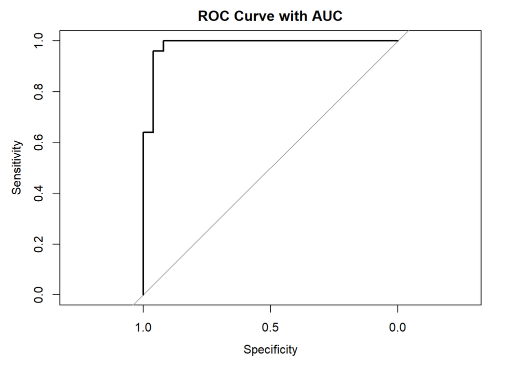

```r
plot(roc_obj, main = "ROC Curve with AUC")
```

> **Commentary**:  
> An AUC of ~0.98 indicates excellent discrimination between classes. The model has strong predictive ability.

## Best Threshold (Youden’s Index)

```r
coords(roc_obj, "best", ret = c("threshold", "sensitivity", "specificity"), best.method = "youden")
```

```
##   threshold sensitivity specificity
## 1 0.2209413        1.00        0.92
## 2 0.4848143        0.96        0.96
```

## Confusion Matrices

```r
thresholds <- c(0.3, 0.5, 0.7)
for (pi0 in thresholds) {
  pred_class <- ifelse(df$pred_prob >= pi0, 1, 0)
  cat("\nThreshold =", pi0, "\n")
  print(table(Predicted = pred_class, Actual = df$above_median_qol))
}
```

```
##
## Threshold = 0.3
##          Actual
## Predicted  0  1
##         0 23  1
##         1  2 24
##
## Threshold = 0.5
##          Actual
## Predicted  0  1
##         0 24  1
##         1  1 24
##
## Threshold = 0.7
##          Actual
## Predicted  0  1
##         0 24  2
##         1  1 23
```

> **Commentary**:  
> Lower thresholds (e.g., 0.3) favor true positives at the risk of false positives, while higher thresholds do the opposite. The 0.5 threshold usually balances both.

## 6. Cross-Validation

### LOOCV

```r
loo_cv <- cv.glm(df, logit_model)
loo_cv$delta[1]  # Error rate
```

```
## [1] 0.06291059
```

### 5-Fold Cross-Validation

```r
set.seed(123)
train_control <- trainControl(method = "cv", number = 5)
cv_model <- train(formula, data = df, method = "glm", family = "binomial", trControl = train_control)
max(cv_model$results$Accuracy)
```

```
## [1] -Inf
```

## 7. Link Function Comparison

```r
probit_model <- glm(formula, data = df, family = binomial(link = "probit"))
AIC(logit_model)
```

```
## [1] 23.93839
```

```r
AIC(probit_model)
```

```
## [1] 24.08117
```

```r
# Identity may fail
identity_model <- tryCatch({
  glm(formula, data = df, family = binomial(link = "identity"))
}, error = function(e) NA)

if (!is.na(identity_model)) AIC(identity_model)
```

> **Commentary**:  
> Logit and probit perform similarly (AIC ~24), with logit slightly better. Identity is not valid for binary classification and fails as expected.